# Tugas Pertemuan 3 - Regresi dengan Peubah Lag

Kualitas Udara New Delhi (AQI vs O3)

Putra Ramadhana

## Packages

```r
library(dLagM)
library(dynlm)
library(MLmetrics)
library(lmtest)
library(car)
```

## Pendahuluan

Tugas ini menerapkan **regresi dengan peubah lag** (Koyck, *Distributed Lag Model*, dan *Autoregressive Distributed Lag*) pada data kualitas udara per jam Kota New Delhi. Variabel dependen (Y) adalah **AQI (Air Quality Index)**, sedangkan variabel independen (X) dipilih dari salah satu polutan yang tersedia (CO, NO2, O3, PM10, PM2.5, SO2).

Sebelum memilih X, dilakukan pengecekan korelasi setiap polutan terhadap AQI agar peubah yang dipakai memang relevan secara statistik.

```r
polusi <- read.csv("C:\\Users\\Roshan\\OneDrive\\Documents\\Kuliah\\MPDW\\Praktikum 3\\NewDelhi_Air_quality (1).csv")
str(polusi)
```

```
## 'data.frame':    72 obs. of  12 variables:
##  $ X              : int  0 1 2 3 4 5 6 7 8 9 ...
##  $ AQI            : num  30.2 28.2 26.6 25 26 26 26 24 23 24 ...
##  $ CO             : num  199 198 199 202 205 ...
##  $ datetime       : chr  "2022-10-21:18" "2022-10-21:19" "2022-10-21:20" "2022-10-21:21" ...
##  $ no2            : num  0.0469 0.0465 0.0469 0.0482 0.0489 ...
##  $ o3             : num  55.8 54.9 54.6 55.1 55.8 ...
##  $ pm10           : num  10.5 10.7 11.2 11.1 10.4 ...
##  $ pm25           : num  5.64 4.62 3.52 2.23 1.98 ...
##  $ so2            : num  0.387 0.41 0.402 0.376 0.339 ...
##  $ timestamp_local: chr  "2022-10-21T23:00:00" "2022-10-22T00:00:00" "2022-10-22T01:00:00" "2022-10-22T02:00:00" ...
##  $ timestamp_utc  : chr  "2022-10-21T18:00:00" "2022-10-21T19:00:00" "2022-10-21T20:00:00" "2022-10-21T21:00:00" ...
##  $ ts             : int  1666375200 1666378800 1666382400 1666386000 1666389600 1666393200 1666396800 1666400400 1666404000 1666407600 ...
```

```r
cor(polusi[, c("AQI","CO","no2","o3","pm10","pm25","so2")])["AQI", ]
```

```
##         AQI          CO         no2          o3        pm10        pm25
##  1.00000000  0.79763320  0.73765472  0.97359901  0.08257568 -0.34665524
##         so2
## -0.74247813
```

Dari matriks korelasi di atas, **O3 (ozon)** memiliki korelasi paling kuat dengan AQI (r ≈ 0.97), jauh lebih tinggi dibanding polutan lain seperti CO (0.80) atau NO2 (0.74). Oleh karena itu, **O3 dipilih sebagai peubah independen (X)** dan **AQI sebagai peubah dependen (Y)**.

## Impor dan Persiapan Data

```r
Period <- 1:nrow(polusi)
AQI <- polusi$AQI
O3  <- polusi$o3

data <- data.frame(Period = Period, AQI = AQI, O3 = O3)
str(data)
```

```
## 'data.frame':    72 obs. of  3 variables:
##  $ Period: int  1 2 3 4 5 6 7 8 9 10 ...
##  $ AQI   : num  30.2 28.2 26.6 25 26 26 26 24 23 24 ...
##  $ O3    : num  55.8 54.9 54.6 55.1 55.8 ...
```

```r
head(data)
```

```
##   Period  AQI       O3
## 1      1 30.2 55.78995
## 2      2 28.2 54.93164
## 3      3 26.6 54.64554
## 4      4 25.0 55.07469
## 5      5 26.0 55.78995
## 6      6 26.0 56.50520
```

Data terdiri atas 72 observasi (pengukuran per jam). Data dibagi menjadi data latih (*train*) sebanyak 60 observasi pertama dan data uji (*test*) sebanyak 12 observasi terakhir, sehingga peramalan dilakukan untuk **h = 12** periode ke depan.

```r
#SPLIT DATA
train <- data[1:60, ]
test  <- data[61:72, ]
```

```r
#data time series
train.ts <- ts(train)
test.ts  <- ts(test)
data.ts  <- ts(data)
```

## Model Koyck

Model Koyck mengasumsikan pengaruh lag dari peubah independen semakin mengecil seiring bertambahnya jarak lag, dan direpresentasikan melalui lag dari peubah dependen itu sendiri ($Y_{t-1}$).

```r
#MODEL KOYCK
model.koyck <- koyckDlm(x = train$O3, y = train$AQI)
summary(model.koyck)
```

```
##
## Call:
## "Y ~ (Intercept) + Y.1 + X.t"
##
## Residuals:
##      Min       1Q   Median       3Q      Max
## -1.06671 -0.42354  0.01392  0.24137  1.09456
##
## Coefficients:
##             Estimate Std. Error t value Pr(>|t|)
## (Intercept) -0.13603    0.83509  -0.163    0.871
## Y.1          0.44327    0.08853   5.007 5.85e-06 ***
## X.t          0.25837    0.04222   6.119 9.71e-08 ***
## ---
## Signif. codes:  0 '***' 0.001 '**' 0.01 '*' 0.05 '.' 0.1 ' ' 1
##
## Residual standard error: 0.5209 on 56 degrees of freedom
## Multiple R-Squared: 0.954,   Adjusted R-squared: 0.9523
## Wald test: 529.1 on 2 and 56 DF,  p-value: < 2.2e-16
##
## Diagnostic tests:
## NULL
##
##                               alpha      beta       phi
## Geometric coefficients:  -0.2443305 0.2583708 0.4432741
```

```r
AIC(model.koyck)
```

```
## [1] 95.39036
```

```r
BIC(model.koyck)
```

```
## [1] 103.7005
```

Hasil di atas menunjukkan bahwa baik $x_t$ (O3 saat ini) maupun $y_{t-1}$ (AQI periode sebelumnya) memiliki nilai p-value < 0.05, artinya keduanya berpengaruh signifikan terhadap AQI. Model yang terbentuk:

$$\hat{Y_t}=-0.1360+0.2584X_t+0.4433Y_{t-1}$$

### Peramalan dan Akurasi

```r
fore.koyck <- forecast(model = model.koyck, x = test$O3, h = 12)
fore.koyck
```

```
## $forecasts
##  [1] 20.53801 19.77881 19.34988 19.62175 20.29667 20.59584 20.72845 21.24924
##  [9] 22.77370 24.55826 26.08852 27.13644
##
## $call
## forecast.koyckDlm(model = model.koyck, x = test$O3, h = 12)
##
## attr(,"class")
## [1] "forecast.koyckDlm" "dLagM"
```

```r
mape.koyck <- MAPE(fore.koyck$forecasts, test$AQI)
mape.koyck
```

```
## [1] 0.03134655
```

```r
GoF(model.koyck)
```

```
##              n       MAE           MPE       MAPE      sMAPE      MASE
## model.koyck 59 0.4000911 -0.0005898125 0.01514439 0.01512203 0.5919716
##                   MSE      MRAE    GMRAE
## model.koyck 0.2575132 518349844 4164.392
```

## Regression with Distributed Lag (DLM)

### Pemodelan (Lag = 2)

```r
model.dlm <- dlm(x = train$O3, y = train$AQI, q = 2)
summary(model.dlm)
```

```
##
## Call:
## lm(formula = model.formula, data = design)
##
## Residuals:
##      Min       1Q   Median       3Q      Max
## -0.47665 -0.34285 -0.00842  0.25203  1.41062
##
## Coefficients:
##              Estimate Std. Error t value Pr(>|t|)
## (Intercept) -0.084981   0.628095  -0.135    0.893
## x.t          0.484610   0.050957   9.510 3.92e-13 ***
## x.1         -0.015772   0.096267  -0.164    0.870
## x.2         -0.006112   0.054062  -0.113    0.910
## ---
## Signif. codes:  0 '***' 0.001 '**' 0.01 '*' 0.05 '.' 0.1 ' ' 1
##
## Residual standard error: 0.3436 on 54 degrees of freedom
## Multiple R-squared:  0.9806, Adjusted R-squared:  0.9795
## F-statistic: 908.4 on 3 and 54 DF,  p-value: < 2.2e-16
##
## AIC and BIC values for the model:
##        AIC      BIC
## 1 46.54734 56.84956
```

```r
AIC(model.dlm)
```

```
## [1] 46.54734
```

```r
BIC(model.dlm)
```

```
## [1] 56.84956
```

Pada lag = 2, hanya $x_t$ (O3 saat ini) yang signifikan secara statistik ($P<0.05$), sedangkan $x_{t-1}$ dan $x_{t-2}$ tidak signifikan. Model yang terbentuk:

$$\hat{Y_t}=-0.0850+0.4846X_t-0.0158X_{t-1}-0.0061X_{t-2}$$

### Peramalan dan Akurasi

```r
fore.dlm <- forecast(model = model.dlm, x = test$O3, h = 12)
fore.dlm
```

```
## $forecasts
##  [1] 20.22287 19.22088 19.09015 19.97546 20.98930 20.94453 20.93141 21.79796
##  [9] 24.19610 26.18592 27.47411 28.09599
##
## $call
## forecast.dlm(model = model.dlm, x = test$O3, h = 12)
##
## attr(,"class")
## [1] "forecast.dlm" "dLagM"
```

```r
mape.dlm <- MAPE(fore.dlm$forecasts, test$AQI)
mape.dlm
```

```
## [1] 0.006720875
```

```r
#akurasi data training
GoF(model.dlm)
```

```
##            n       MAE           MPE        MAPE       sMAPE      MASE
## model.dlm 58 0.2595166 -0.0001434091 0.009670027 0.009680499 0.3934161
##                 MSE      MRAE    GMRAE
## model.dlm 0.1099477 985693475 3428.508
```

### Lag Optimum

```r
#penentuan lag optimum
finiteDLMauto(formula = AQI ~ O3,
              data = data.frame(train), q.min = 1, q.max = 10,
              model.type = "dlm", error.type = "AIC", trace = TRUE)
```

```
##    q - k    MASE      AIC       BIC    GMRAE   MBRAE R.Adj.Sq  Ljung-Box
## 10    10 0.32961 24.00608  48.86238 6976.708 0.46014  0.98735 0.39692632
## 5      5 0.35026 25.86841  41.92707 4125.769 0.46270  0.98661 0.17857837
## 3      3 0.36862 26.27835  38.53666 3836.000 0.46275  0.98593 0.10233137
## 4      4 0.36754 27.03577  41.21323 4974.052 0.46558  0.98597 0.16054468
## 6      6 0.34803 28.50797  46.40883 3198.518 0.45243  0.98629 0.18765677
## 9      9 0.35059 28.94640  52.12831 5730.892 0.46613  0.98613 0.73691560
## 7      7 0.35812 29.52828  49.23120 3827.478 0.45741  0.98636 0.26785094
## 8      8 0.36221 29.94617  51.40985 4857.959 0.47703  0.98624 0.41190621
## 2      2 0.39342 46.54734  56.84956 3428.508 0.45674  0.97949 0.08540349
## 1      1 0.46442 92.75107 101.06122 3656.581 0.36990  0.95439 0.14844739
```

Berdasarkan output tersebut, lag optimum (AIC terkecil pada rentang yang diuji) didapatkan pada **lag = 10**. Selanjutnya dilakukan pemodelan dengan lag tersebut.

```r
#model dlm dengan lag optimum
model.dlm2 <- dlm(x = train$O3, y = train$AQI, q = 10)
summary(model.dlm2)
```

```
##
## Call:
## lm(formula = model.formula, data = design)
##
## Residuals:
##      Min       1Q   Median       3Q      Max
## -0.51839 -0.17484  0.04678  0.19294  0.53415
##
## Coefficients:
##             Estimate Std. Error t value Pr(>|t|)
## (Intercept) -0.19367    0.81489  -0.238  0.81342
## x.t          0.42755    0.06131   6.974 2.67e-08 ***
## x.1          0.12033    0.13099   0.919  0.36408
## x.2         -0.04877    0.12590  -0.387  0.70062
## x.3         -0.13989    0.12124  -1.154  0.25577
## x.4          0.16324    0.12402   1.316  0.19600
## x.5         -0.02438    0.12287  -0.198  0.84377
## x.6         -0.13088    0.12307  -1.063  0.29429
## x.7          0.27643    0.12166   2.272  0.02883 *
## x.8         -0.36216    0.11967  -3.026  0.00443 **
## x.9          0.27418    0.10224   2.682  0.01078 *
## x.10        -0.09167    0.04765  -1.924  0.06187 .
## ---
## Signif. codes:  0 '***' 0.001 '**' 0.01 '*' 0.05 '.' 0.1 ' ' 1
##
## Residual standard error: 0.2721 on 38 degrees of freedom
## Multiple R-squared:  0.9902, Adjusted R-squared:  0.9873
## F-statistic: 348.7 on 11 and 38 DF,  p-value: < 2.2e-16
##
## AIC and BIC values for the model:
##        AIC      BIC
## 1 24.00608 48.86238
```

```r
AIC(model.dlm2)
```

```
## [1] 24.00608
```

```r
BIC(model.dlm2)
```

```
## [1] 48.86238
```

Dengan lag = 10, beberapa peubah lag (di antaranya $x_{t}$, $x_{t-7}$, $x_{t-8}$, $x_{t-9}$) signifikan pada taraf nyata 5%. Model ini memiliki $R^2$ yang lebih tinggi (0.99) dibanding model lag = 2, namun dengan jumlah parameter yang jauh lebih banyak (risiko *overfitting* pada data latih).

### Peramalan dan Akurasi

```r
#peramalan dan akurasi
fore.dlm2 <- forecast(model = model.dlm2, x = test$O3, h = 12)

#akurasi data test
mape.dlm2 <- MAPE(fore.dlm2$forecasts, test$AQI)
mape.dlm2
```

```
## [1] 0.01077094
```

```r
#akurasi data training
GoF(model.dlm2)
```

```
##             n       MAE           MPE        MAPE       sMAPE      MASE
## model.dlm2 50 0.2018042 -5.793419e-05 0.007500601 0.007495252 0.3296136
##                  MSE      MRAE    GMRAE
## model.dlm2 0.0562609 851166567 6976.708
```

## Model Autoregressive (ARDL)

### Pemodelan

```r
model.ardl <- ardlDlm(formula = AQI ~ O3, data = train, p = 1, q = 1)
summary(model.ardl)
```

```
##
## Time series regression with "ts" data:
## Start = 2, End = 60
##
## Call:
## dynlm(formula = as.formula(model.text), data = data)
##
## Residuals:
##     Min      1Q  Median      3Q     Max
## -1.0293 -0.2749  0.1206  0.2801  0.8761
##
## Coefficients:
##             Estimate Std. Error t value Pr(>|t|)
## (Intercept) -0.06906    0.60255  -0.115    0.909
## O3.t         0.47975    0.03029  15.838  < 2e-16 ***
## O3.1        -0.22506    0.04359  -5.163 3.45e-06 ***
## AQI.1        0.45020    0.06453   6.976 4.12e-09 ***
## ---
## Signif. codes:  0 '***' 0.001 '**' 0.01 '*' 0.05 '.' 0.1 ' ' 1
##
## Residual standard error: 0.3744 on 55 degrees of freedom
## Multiple R-squared:  0.9766, Adjusted R-squared:  0.9754
## F-statistic: 766.5 on 3 and 55 DF,  p-value: < 2.2e-16
```

```r
AIC(model.ardl)
```

```
## [1] 57.35211
```

```r
BIC(model.ardl)
```

```
## [1] 67.7398
```

Hasil uji-t menunjukkan bahwa peubah $x_t$ (O3 saat ini), $x_{t-1}$ (O3 lag 1), dan $y_{t-1}$ (AQI lag 1) semuanya berpengaruh signifikan terhadap AQI ($P<0.05$). Model keseluruhan:

$$\hat{Y_t}=-0.0691+0.4798X_t-0.2251X_{t-1}+0.4502Y_{t-1}$$

### Peramalan dan Akurasi

```r
fore.ardl <- forecast(model = model.ardl, x = test$O3, h = 12)
fore.ardl
```

```
## $forecasts
##  [1] 20.26618 19.22834 19.07248 19.94064 20.95847 20.93376 20.92264 21.77548
##  [9] 24.15897 26.16401 27.47338 28.10522
##
## $call
## forecast.ardlDlm(model = model.ardl, x = test$O3, h = 12)
##
## attr(,"class")
## [1] "forecast.ardlDlm" "dLagM"
```

```r
mape.ardl <- MAPE(fore.ardl$forecasts, test$AQI)
mape.ardl
```

```
## [1] 0.007112712
```

```r
#akurasi data training
GoF(model.ardl)
```

```
##             n       MAE           MPE       MAPE      sMAPE      MASE       MSE
## model.ardl 59 0.3076814 -0.0001639711 0.01147448 0.01146312 0.4552429 0.1306414
##                  MRAE    GMRAE
## model.ardl 1063180549 4541.336
```

### Lag dan Ordo Optimum

```r
#penentuan lag dan ordo optimum
model.ardl.opt <- ardlBoundOrders(data = data.frame(train), ic = "AIC",
                                   formula = AQI ~ O3)
model.ardl.opt
```

```
## $p
##   O3
## 1 12
##
## $q
## [1] 15
##
## $Stat.table
##           q = 1    q = 2    q = 3    q = 4    q = 5    q = 6    q = 7    q = 8
## p = 1  41.37375 26.23382 28.29676 30.72410 30.85189 31.08840 33.26793 35.26002
## p = 2  25.81834 27.81287 30.24668 32.10110 31.94300 31.09085 33.37543 35.36368
## p = 3  30.33603 30.33603 32.23086 34.09715 33.94166 30.56281 33.22371 35.17516
## p = 4  29.84902 31.33515 31.33515 30.09252 32.82305 32.52481 34.73207 36.97280
## p = 5  31.28732 32.22877 32.90884 32.90884 34.56951 34.39784 36.72334 38.66709
## p = 6  32.45297 33.84173 32.79584 34.62766 34.62766 36.38977 38.44476 40.61883
## p = 7  34.54586 35.54209 34.38214 35.47760 36.79637 36.79637 35.30202 33.09451
## p = 8  29.91310 31.10590 31.53263 33.07624 33.04729 34.92041 34.92041 34.80100
## p = 9  28.85771 30.34023 29.70000 31.69890 31.86722 33.53711 35.45086 35.45086
## p = 10 31.28848 32.80430 31.31849 33.22056 32.16296 33.92993 35.91637 37.68798
## p = 11 29.98655 29.29361 29.05880 30.95355 30.17415 32.06348 33.41784 35.22290
## p = 12 31.81131 30.99337 30.15158 32.14763 31.92522 33.86285 34.55563 35.75486
## p = 13 22.59037 19.40309 21.05773 20.64394 18.25530 19.92465 20.08112 21.79499
## p = 14 23.92323 20.73909 21.91305 23.38058 17.71546 19.50489 17.28983 19.26228
## p = 15 26.08804 21.78912 22.36668 22.20755 19.34629 18.66652 19.05164 20.73621
##           q = 9   q = 10    q = 11     q = 12     q = 13     q = 14      q = 15
## p = 1  36.83622 36.65300 37.667241 38.3043389 40.2026723 35.4931215  27.8117279
## p = 2  37.36070 38.44506 38.477075 38.9064620 40.9774844 36.5586824  27.8825112
## p = 3  36.01350 37.13353 38.898737 39.1669076 39.9505861 35.6199987  25.9577630
## p = 4  37.96618 39.06713 40.874852 41.1668921 41.4046091 36.4754508  26.1606694
## p = 5  39.57112 40.50510 42.135797 42.9505096 43.4044855 38.4665610  27.5436276
## p = 6  39.76147 40.77435 41.606660 42.9699724 44.6397314 36.3349127  20.3187179
## p = 7  35.73813 38.36900 39.774214 41.5861546 43.3588210 32.4904514  15.3062980
## p = 8  35.86164 38.41527 34.792955 36.0500356 36.8748960 28.0851698  17.0687828
## p = 9  37.02478 40.03787 34.955630 34.9566386 34.7329361 21.3982009  -0.9106365
## p = 10 37.68798 38.30541 30.519065 31.9669567 32.3382407 20.7211683   0.6833613
## p = 11 31.35586 31.35586 31.398135 33.9660136 33.9912205 21.7946907   1.6797365
## p = 12 32.44303 34.44012 34.440121 35.9607717 31.2733268  8.0342584 -11.2375093
## p = 13 17.46481 18.46700 15.753312 15.7533119 17.5246880  9.9573544 -10.1198467
## p = 14 17.32634 18.71119 19.557188 -0.6264836 -0.6264836  0.9775662  -8.2500803
## p = 15 13.14080 11.18933  7.998972  3.0809846 -2.1838942 -2.1838942  -6.7715377
##
## $min.Stat
## [1] -11.23751
```

```r
min_p <- c()
for (i in 1:6) {
  min_p[i] <- min(model.ardl.opt$Stat.table[[i]])
}
q_opt <- which(min_p == min(min_p, na.rm = TRUE))
p_opt <- which(model.ardl.opt$Stat.table[[q_opt]] ==
               min(model.ardl.opt$Stat.table[[q_opt]], na.rm = TRUE))
data.frame("q_optimum" = q_opt, "p_optimum" = p_opt,
           "AIC" = model.ardl.opt$min.Stat)
```

```
##   q_optimum p_optimum       AIC
## 1         5        14 -11.23751
```

Kombinasi ordo $p$ dan $q$ optimum di atas dapat dijadikan acuan pemodelan ARDL lanjutan, namun pada tugas ini pembandingan akhir tetap difokuskan pada model ARDL(1,1) di atas agar sebanding dengan model Koyck dan DLM yang parsimoni.

## Pemodelan dengan Library `dynlm`

Sebagai pembanding, model-model di atas juga direpresentasikan dengan `dynlm` beserta fungsi `L()` untuk mengambil nilai lag.

```r
#sama dengan model dlm q=1
cons_lm1 <- dynlm(AQI ~ O3 + L(O3), data = train.ts)

#sama dengan model ardl p=1 q=0
cons_lm2 <- dynlm(AQI ~ O3 + L(AQI), data = train.ts)

#sama dengan ardl p=1 q=1
cons_lm3 <- dynlm(AQI ~ O3 + L(O3) + L(AQI), data = train.ts)

#sama dengan dlm q=2
cons_lm4 <- dynlm(AQI ~ O3 + L(O3) + L(O3, 2), data = train.ts)
```

### Ringkasan Model

```r
summary(cons_lm1)
```

```
##
## Time series regression with "ts" data:
## Start = 2, End = 60
##
## Call:
## dynlm(formula = AQI ~ O3 + L(O3), data = train.ts)
##
## Residuals:
##      Min       1Q   Median       3Q      Max
## -0.49478 -0.39127 -0.07745  0.21660  2.81893
##
## Coefficients:
##             Estimate Std. Error t value Pr(>|t|)
## (Intercept)  0.25513    0.81739   0.312    0.756
## O3           0.47664    0.04121  11.567   <2e-16 ***
## L(O3)       -0.01894    0.04361  -0.434    0.666
## ---
## Signif. codes:  0 '***' 0.001 '**' 0.01 '*' 0.05 '.' 0.1 ' ' 1
##
## Residual standard error: 0.5094 on 56 degrees of freedom
## Multiple R-squared:  0.956,  Adjusted R-squared:  0.9544
## F-statistic: 607.9 on 2 and 56 DF,  p-value: < 2.2e-16
```

```r
summary(cons_lm2)
```

```
##
## Time series regression with "ts" data:
## Start = 2, End = 60
##
## Call:
## dynlm(formula = AQI ~ O3 + L(AQI), data = train.ts)
##
## Residuals:
##     Min      1Q  Median      3Q     Max
## -0.7588 -0.2902 -0.0460  0.2432  1.8094
##
## Coefficients:
##             Estimate Std. Error t value Pr(>|t|)
## (Intercept) -0.66901    0.71395  -0.937 0.352759
## O3           0.36926    0.02589  14.264  < 2e-16 ***
## L(AQI)       0.22436    0.05729   3.916 0.000247 ***
## ---
## Signif. codes:  0 '***' 0.001 '**' 0.01 '*' 0.05 '.' 0.1 ' ' 1
##
## Residual standard error: 0.4521 on 56 degrees of freedom
## Multiple R-squared:  0.9653, Adjusted R-squared:  0.9641
## F-statistic: 779.3 on 2 and 56 DF,  p-value: < 2.2e-16
```

```r
summary(cons_lm3)
```

```
##
## Time series regression with "ts" data:
## Start = 2, End = 60
##
## Call:
## dynlm(formula = AQI ~ O3 + L(O3) + L(AQI), data = train.ts)
##
## Residuals:
##     Min      1Q  Median      3Q     Max
## -1.0293 -0.2749  0.1206  0.2801  0.8761
##
## Coefficients:
##             Estimate Std. Error t value Pr(>|t|)
## (Intercept) -0.06906    0.60255  -0.115    0.909
## O3           0.47975    0.03029  15.838  < 2e-16 ***
## L(O3)       -0.22506    0.04359  -5.163 3.45e-06 ***
## L(AQI)       0.45020    0.06453   6.976 4.12e-09 ***
## ---
## Signif. codes:  0 '***' 0.001 '**' 0.01 '*' 0.05 '.' 0.1 ' ' 1
##
## Residual standard error: 0.3744 on 55 degrees of freedom
## Multiple R-squared:  0.9766, Adjusted R-squared:  0.9754
## F-statistic: 766.5 on 3 and 55 DF,  p-value: < 2.2e-16
```

```r
summary(cons_lm4)
```

```
##
## Time series regression with "ts" data:
## Start = 3, End = 60
##
## Call:
## dynlm(formula = AQI ~ O3 + L(O3) + L(O3, 2), data = train.ts)
##
## Residuals:
##      Min       1Q   Median       3Q      Max
## -0.47665 -0.34285 -0.00842  0.25203  1.41062
##
## Coefficients:
##              Estimate Std. Error t value Pr(>|t|)
## (Intercept) -0.084981   0.628095  -0.135    0.893
## O3           0.484610   0.050957   9.510 3.92e-13 ***
## L(O3)       -0.015772   0.096267  -0.164    0.870
## L(O3, 2)    -0.006112   0.054062  -0.113    0.910
## ---
## Signif. codes:  0 '***' 0.001 '**' 0.01 '*' 0.05 '.' 0.1 ' ' 1
##
## Residual standard error: 0.3436 on 54 degrees of freedom
## Multiple R-squared:  0.9806, Adjusted R-squared:  0.9795
## F-statistic: 908.4 on 3 and 54 DF,  p-value: < 2.2e-16
```

### SSE

```r
deviance(cons_lm1)
```

```
## [1] 14.5286
```

```r
deviance(cons_lm2)
```

```
## [1] 11.44385
```

```r
deviance(cons_lm3)
```

```
## [1] 7.707844
```

```r
deviance(cons_lm4)
```

```
## [1] 6.376966
```

### Uji Encompassing

```r
#uji model
if (require("lmtest")) encomptest(cons_lm1, cons_lm2)
```

```
## Encompassing test
##
## Model 1: AQI ~ O3 + L(O3)
## Model 2: AQI ~ O3 + L(AQI)
## Model E: AQI ~ O3 + L(O3) + L(AQI)
##           Res.Df Df      F    Pr(>F)
## M1 vs. ME     55 -1 48.670 4.123e-09 ***
## M2 vs. ME     55 -1 26.659 3.453e-06 ***
## ---
## Signif. codes:  0 '***' 0.001 '**' 0.01 '*' 0.05 '.' 0.1 ' ' 1
```

- **Model 1** (hanya lag X): melawan model gabungan, penambahan lag Y memberikan peningkatan yang **signifikan** (p-value ≪ 0.05). Artinya Model 1 saja belum memadai.
- **Model 2** (hanya lag Y): melawan model gabungan, penambahan lag X juga memberikan peningkatan yang **signifikan** (p-value ≪ 0.05). Artinya Model 2 saja belum memadai.

Kesimpulannya, kedua peubah (lag X dan lag Y) sama-sama dibutuhkan — konsisten dengan struktur model ARDL.

#### Uji Autokorelasi Residual

```r
#durbin watson
dwtest(cons_lm1)
```

```
##
##  Durbin-Watson test
##
## data:  cons_lm1
## DW = 1.0862, p-value = 3.612e-05
## alternative hypothesis: true autocorrelation is greater than 0
```

```r
dwtest(cons_lm2)
```

```
##
##  Durbin-Watson test
##
## data:  cons_lm2
## DW = 1.6151, p-value = 0.0374
## alternative hypothesis: true autocorrelation is greater than 0
```

```r
dwtest(cons_lm3)
```

```
##
##  Durbin-Watson test
##
## data:  cons_lm3
## DW = 2.7567, p-value = 0.9963
## alternative hypothesis: true autocorrelation is greater than 0
```

```r
dwtest(cons_lm4)
```

```
##
##  Durbin-Watson test
##
## data:  cons_lm4
## DW = 2.1251, p-value = 0.5787
## alternative hypothesis: true autocorrelation is greater than 0
```

Model 1 dan Model 2 menunjukkan indikasi autokorelasi positif (p-value < 0.05), sedangkan Model 3 dan Model 4 tidak menunjukkan autokorelasi residual yang signifikan (p-value > 0.05).

#### Uji Heteroskedastisitas

```r
bptest(cons_lm1)
```

```
##
##  studentized Breusch-Pagan test
##
## data:  cons_lm1
## BP = 0.58273, df = 2, p-value = 0.7472
```

```r
bptest(cons_lm2)
```

```
##
##  studentized Breusch-Pagan test
##
## data:  cons_lm2
## BP = 23.017, df = 2, p-value = 1.004e-05
```

```r
bptest(cons_lm3)
```

```
##
##  studentized Breusch-Pagan test
##
## data:  cons_lm3
## BP = 14.989, df = 3, p-value = 0.001826
```

```r
bptest(cons_lm4)
```

```
##
##  studentized Breusch-Pagan test
##
## data:  cons_lm4
## BP = 0.69016, df = 3, p-value = 0.8755
```

- Jika p-value > 0.05 → tidak ada heteroskedastisitas.
- Jika p-value ≤ 0.05 → ada heteroskedastisitas.

Model 2 dan Model 3 terindikasi mengalami heteroskedastisitas (p-value < 0.05), sedangkan Model 1 dan Model 4 tidak.

#### Uji Normalitas

H0: Residual berdistribusi normal. H1: Residual tidak berdistribusi normal.

```r
shapiro.test(residuals(cons_lm1))
```

```
##
##  Shapiro-Wilk normality test
##
## data:  residuals(cons_lm1)
## W = 0.677, p-value = 4.088e-10
```

```r
shapiro.test(residuals(cons_lm2))
```

```
##
##  Shapiro-Wilk normality test
##
## data:  residuals(cons_lm2)
## W = 0.93116, p-value = 0.002456
```

```r
shapiro.test(residuals(cons_lm3))
```

```
##
##  Shapiro-Wilk normality test
##
## data:  residuals(cons_lm3)
## W = 0.96475, p-value = 0.08514
```

```r
shapiro.test(residuals(cons_lm4))
```

```
##
##  Shapiro-Wilk normality test
##
## data:  residuals(cons_lm4)
## W = 0.85584, p-value = 6.197e-06
```

- Jika p-value > 0.05 → gagal tolak H0 → residual normal.
- Jika p-value ≤ 0.05 → tolak H0 → residual tidak normal.

Hanya Model 3 (setara ARDL(1,1)) yang residualnya berdistribusi normal (p-value > 0.05); model lainnya menyimpang dari asumsi normalitas.

## Perbandingan Model

```r
akurasi <- matrix(c(mape.koyck, mape.dlm, mape.dlm2, mape.ardl))
row.names(akurasi) <- c("Koyck", "DLM (lag=2)", "DLM (lag optimum=10)", "Autoregressive (ARDL 1,1)")
colnames(akurasi) <- c("MAPE")
akurasi
```

```
##                                  MAPE
## Koyck                     0.031346552
## DLM (lag=2)               0.006720875
## DLM (lag optimum=10)      0.010770937
## Autoregressive (ARDL 1,1) 0.007112712
```

Berdasarkan nilai MAPE pada data uji, **model DLM dengan lag = 2 memberikan hasil paling akurat** (MAPE terkecil), diikuti oleh model ARDL(1,1), kemudian DLM dengan lag optimum (=10), dan terakhir model Koyck dengan MAPE terbesar. Model dengan lag “optimum” hasil `finiteDLMauto` justru memberikan akurasi peramalan pada data uji yang lebih buruk dibanding model DLM lag=2 yang lebih sederhana, ini adalah indikasi *overfitting*: model dengan lebih banyak parameter cocok sangat baik pada data latih, tetapi kurang mampu menggeneralisasi ke data baru. Hal ini menegaskan pentingnya validasi pada data uji, bukan hanya mengandalkan kriteria AIC/BIC pada data latih semata.

### Plot Perbandingan

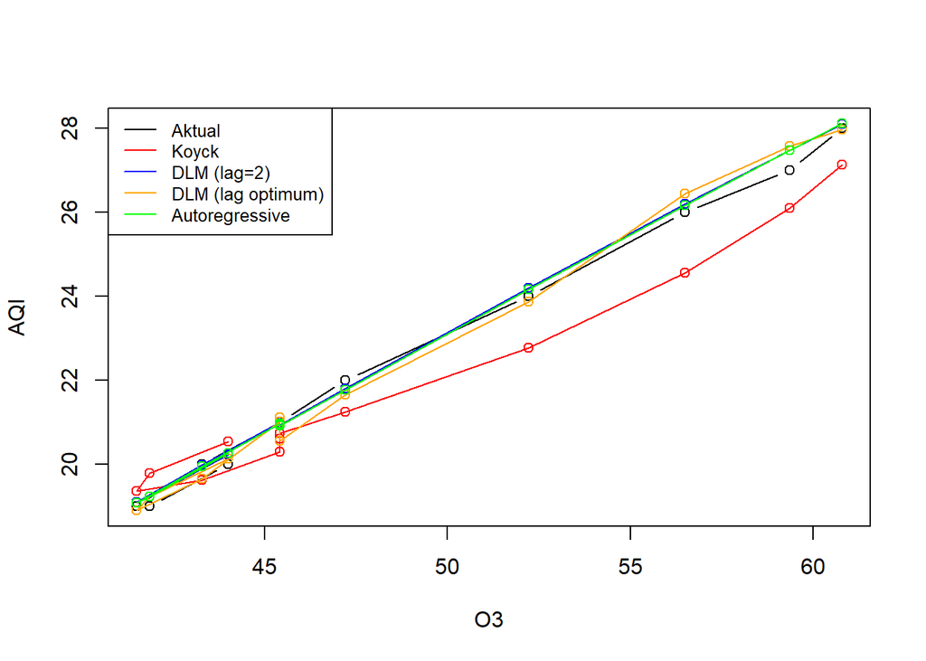

```r
par(mfrow = c(1, 1))

# plot data aktual
plot(test$O3, test$AQI, type = "b", col = "black",
     ylim = range(c(test$AQI, fore.koyck$forecasts, fore.dlm$forecasts,
                    fore.dlm2$forecasts, fore.ardl$forecasts)),
     xlab = "O3", ylab = "AQI")

# tambahkan garis ramalan dari masing-masing model
points(test$O3, fore.koyck$forecasts, col = "red");    lines(test$O3, fore.koyck$forecasts, col = "red")
points(test$O3, fore.dlm$forecasts, col = "blue");     lines(test$O3, fore.dlm$forecasts, col = "blue")
points(test$O3, fore.dlm2$forecasts, col = "orange");  lines(test$O3, fore.dlm2$forecasts, col = "orange")
points(test$O3, fore.ardl$forecasts, col = "green");   lines(test$O3, fore.ardl$forecasts, col = "green")

# legenda model
legend("topleft",
       c("Aktual", "Koyck", "DLM (lag=2)", "DLM (lag optimum)", "Autoregressive"),
       lty = 1, col = c("black", "red", "blue", "orange", "green"), cex = 0.8)
```

Dari plot di atas, garis ramalan model **DLM (lag=2)** dan **Autoregressive (ARDL)** paling mendekati garis data aktual pada seluruh periode uji, sejalan dengan nilai MAPE keduanya yang terkecil. Model DLM dengan lag optimum (oranye) tampak lebih menyimpang di beberapa titik akibat kompleksitas model yang berlebih (overfitting), sementara model Koyck (merah) menunjukkan penyimpangan paling besar di antara keempat model.